# STAT 1261/2260 Homework 6

Rayan Hassan

2023-11-05

# Exercise 1

```r
library(NHANES)
library(tidyverse)
data1<- NHANES %>%
  select(HardDrugs,Gender,HealthGen,Depressed,SleepHrsNight,AlcoholDay, SmokeNow, Marijuana) %>% na.omit()
glimpse(data1)
```

```
## Rows: 1,704
## Columns: 8
## $ HardDrugs     <fct> Yes, No, No, Yes, Yes, No, Yes, Yes, Yes, No, No, No, No…
## $ Gender        <fct> female, male, female, male, male, male, male, female, fe…
## $ HealthGen     <fct> Good, Fair, Excellent, Fair, Excellent, Excellent, Excel…
## $ Depressed     <fct> Several, None, None, None, Several, None, None, None, No…
## $ SleepHrsNight <int> 8, 6, 8, 6, 6, 6, 8, 4, 4, 6, 6, 6, 6, 6, 5, 8, 8, 8, 8,…
## $ AlcoholDay    <int> 2, 3, 1, 6, 3, 12, 5, 3, 3, 7, 7, 7, 7, 1, 4, 1, 1, 1, 1…
## $ SmokeNow      <fct> Yes, No, No, Yes, Yes, Yes, Yes, Yes, Yes, Yes, Yes, Yes…
## $ Marijuana     <fct> Yes, No, Yes, No, Yes, Yes, Yes, Yes, Yes, Yes, Yes, Yes…
```

# Exercise 1

```r
set.seed(99)
train1 <- data1 %>% sample_frac(size = 0.8)
test1 <- data1 %>% setdiff(train1)


library(glmnet)
form<- as.formula(
  "HardDrugs ~Gender+HealthGen+Depressed+SleepHrsNight+AlcoholDay+SmokeNow+Marijuana")
predictors <- model.matrix(form, data = train1)
cv.fit <- cv.glmnet(predictors, train1$HardDrugs, family = "binomial", type = "class")
cv.fit$lambda.1se
```

```
## [1] 0.02558189
```

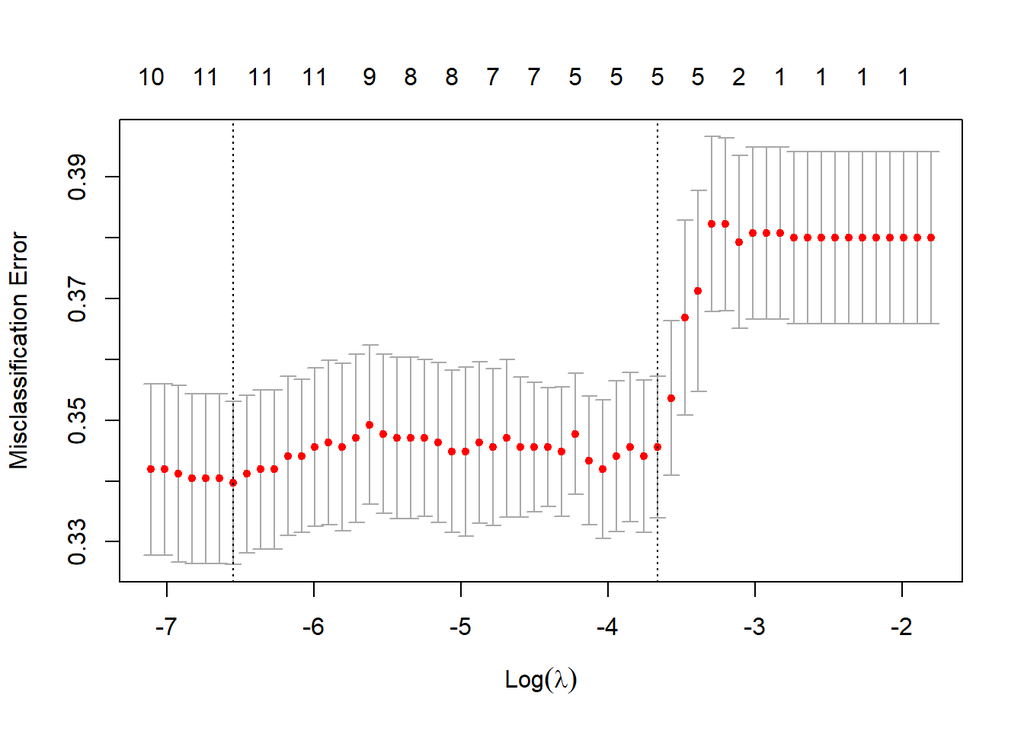

```r
plot(cv.fit)
```

```r
lambda_opt=cv.fit$lambda.1se
mod_lr <- glmnet(predictors, train1$HardDrugs, family = "binomial", lambda = lambda_opt)
mod_lr$beta
```

```
## 12 x 1 sparse Matrix of class "dgCMatrix"
##                          s0
## (Intercept)      .
## Gendermale       0.19515911
## HealthGenVgood   .
## HealthGenGood    .
## HealthGenFair    .
## HealthGenPoor    .
## DepressedSeveral 0.35997057
## DepressedMost    0.25541222
## SleepHrsNight    .
## AlcoholDay       0.01346756
## SmokeNowYes      .
## MarijuanaYes     2.06711656
```

```r
form2 <- as.formula(HardDrugs~Gender+Depressed+AlcoholDay+Marijuana)
mod_lr2 <- glm(form2, data=train1,family=binomial)
summary(mod_lr2)
```

```
##
## Call:
## glm(formula = form2, family = binomial, data = train1)
##
## Coefficients:
##                  Estimate Std. Error z value Pr(>|z|)
## (Intercept)      -3.94152    0.34909 -11.291  < 2e-16 ***
## Gendermale        0.51475    0.12882   3.996 6.45e-05 ***
## DepressedSeveral  0.72179    0.15015   4.807 1.53e-06 ***
## DepressedMost     0.91592    0.24315   3.767 0.000165 ***
## AlcoholDay        0.03929    0.01872   2.099 0.035833 *
## MarijuanaYes      3.11054    0.33172   9.377  < 2e-16 ***
## ---
## Signif. codes:  0 '***' 0.001 '**' 0.01 '*' 0.05 '.' 0.1 ' ' 1
##
## (Dispersion parameter for binomial family taken to be 1)
##
##     Null deviance: 1810.3  on 1362  degrees of freedom
## Residual deviance: 1555.5  on 1357  degrees of freedom
## AIC: 1567.5
##
## Number of Fisher Scoring iterations: 5
```

# Exercise 2

The variable that is most significant is MarijuanaYes with the smallest p-value of < 2e-16

# Exercise 3

The coefficient of MarijuanaYes is 3.11054 (positive). So it is a positive direction which indicated that individuals who use Marijuana are more likely to use hard drugs. In terms of strength, MarijuanaYes has a very small p-value of less then 2e-16 (almost close to zero), which suggests that the relationship between Marijuana and HardDrugs is extremely strong.

# Exercise 4

Gendermale has a very small p-value (around 6.5e-5) which indicates that Gendermale is a significant variable. Also, it has a coefficient of 0.51475, which is positive. This suggests that males are more likely to use hard drugs and that the relationship between both is very strong

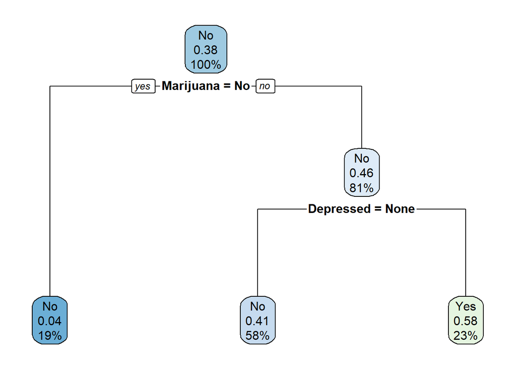

```r
library(rpart)
library(rpart.plot)
mod_tree <- rpart(form2,data=train1)
rpart.plot(mod_tree)
```

# Exercise 5

The most important predictor seems to be Marijuana. Only 4% of people that don’t do Marijuana do Hard Drugs versus 46% that smoke Marijuana. This difference is huge and shows how much smoking Marijuana leads to hard drugs.

# Exercise 6

The two subgroups that are most likely to use hard drugs are Marijuana which we explained before (so if person smokes marijuana) and if person is Depressed. 58% of people that do Marijuana and that are Depressed do Hard Drugs. Whereas 41% people who do Marijuana but are not Depressed do Hard Drugs. Which shows that in addition to smoking Marijuana, Depression is also a significant factor.